# STA257

Last edited: 2016-10-18 11:23

## some simplified notation

It is common to deal with probabilities of intersections of events relating to random variables.

\[P(\{X \le 3\} \cap \{Y > 5\})\] Usually we omit the braces and use a comma:

\[P(X \le 3,\,Y > 5)\]

## recap

A Poisson process \(N(t)\) counts the number of event that happen between "time" 0 and "time" \(t\).

The rate per unit time is \(\lambda\).

Probability of \(k\) events between times \(s\) and \(t\) are: \[P(N(t) - N(s) = k) = \frac{[\lambda(t-s)]^ke^{-\lambda(t-s)}}{k!}\] and \(N(0)=0\) always, so when dealing with intervals \((0,t]\) we can just use \[P(N(t)=k) = \frac{[\lambda t ]^ke^{-\lambda t}}{k!}.\]

## practical examples (stolen from *Schay*)

Q7.1.1 (p. 236) Customers enter a store at a rate of 1 per minute. Find the probabilities that:

1. More than one will enter in the first minute. *(from last time: 0.264)*
2. More than two will enter in the first two minutes. (0.323)
3. More than one will enter in each of the first two minutes. \(\left(0.264^2\right)\)

## DISASTROUS TREND SHOCKER PANIC HEADLINE

## which ones are "completely random" (Poisson?)

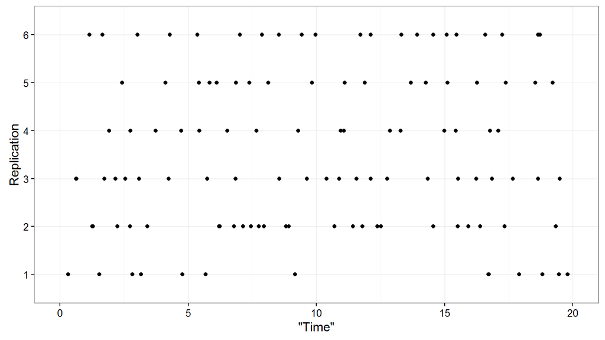

Answer: 1, 2, 4

## continuous random variables

## from counting to measuring

Discrete random variables *count* things.

We need random variables to *measure* things.

Let \(X\) be such a random variable. As always it will have a cdf \(F(x) = P(X\le x)\), which will turn out to be *continuous*.

Main focus as always is on *distribution*, i.e. the collection of \(P(X \in A)\) for \(A \subset \mathbb{R}\).

Let's just worry about intervals and consider things like:

\[P(X \in (a,b]) = P(a < X \le b) = F(b) - F(a).\]

## density

If there is a ("piecewise") continuous function \(f\) such that:

\[P(a < X \le b) = F(b) - F(a) = \int_a^b f(x)\,dx\] then we say \(X\) is "(absolutely) continuous" and has \(f\) as its *probability density function* (or pdf, or just density).

Note: \(a\) and \(b\) can be \(-\infty\) or \(\infty\).

## density functions, meanings, consequences - I

Theorem: A pdf completely characterizes a distribution.

Proof: …

Some corollaries: the cdf \(F\) is continuous, \(f \ge 0\) (wherever it is continuous), and \(\int_{-\infty}^\infty f(x)\,dx = 1\).

Theorem: Any piecewise continuous, non-negative \(f\) with \(\int f = 1\) can be a density function.

Proof: Too hard…

## density functions, meanings, consequences - II

Advice: *Always* think of a density as living inside its integral.

Heuristic meaning of \(f(x)\) can be:

\[f(x)\Delta{x} \approx \int_x^{x+\Delta{x}}f(x)\,dx = P(X \in (x, x+\Delta x]).\]

Pictures of densities can be useful, to show relative differences in probabilities.

## density functions, meanings, consequences - III

If \(X\) is continuous, then for all \(a \in \mathbb{R}\):

\[P(X = a) = P(X \in (a, a]) = \int_a^a f(x)\,dx = 0\]

Recall from the beginning "pick a random number in (0,1)" and its associated oddities.

For continuous random variables we have these conveniences:

\[P(a < X \le b) = P(a \le X < b) = P(a \le X \le b), \text{ etc.}\]

## example

Pick a number "uniformly" from \((0,1)\) and let \(X\) simply be that number. We have:

\[F(x) = P(X \le x) = \begin{cases} 0 &: x < 0\\ x &: 0 \le x < 1\\ 1 &: x \ge 1\end{cases}\]

To find the density, just differentiate:

\[f(x) = F'(x) = \begin{cases} 1 &: 0 \le x < 1\\ 0 &: \text{otherwise}\end{cases}\]

The endpoints don't matter. We say \(X\) has a uniform distribution with parameters 0 and 1, or \(X\sim\text{Uniform}[0,1]\).

## the \(\text{Uniform}[a,b]\) distributions

Nothing special about 0 and 1. Pick a number between \(a\) and \(b\) and call it \(X\). The density and cdf will be:

\[f(x) = \begin{cases} \frac{1}{b-a} &: x \in [a,b]\\ 0 &: \text{otherwise};\end{cases}\] \[F(x) = \begin{cases} 0 &: x < a\\ \frac{x-a}{b-a} &: x \in [a,b]\\ 1 &: x > b.\end{cases}\]

The density is used to calculate probabilities. Say \(X \sim\text{Uniform}[-1, 2]\). We can calculate things like: \(P(0 < X < 3/2)\), \(P(-3 < X \le 0)\), etc.

## an (apparently) artificial example

Suppose \(f\) is defined as: \[f(x) = \begin{cases} cx &: 0<x\le 1,\\ c(2-x) &: 1 < x \le 2,\\ 0 &: \text{ otherwise.} \end{cases}\]

Determine \(c\) that makes \(f\) a valid density.

If \(X\) has \(f\) as its density, determine its cdf and calculate \(P(0.75 < X < 1.5)\).